# STAT 626 Project - Version 3

### Model Formulation: Total Meat Production

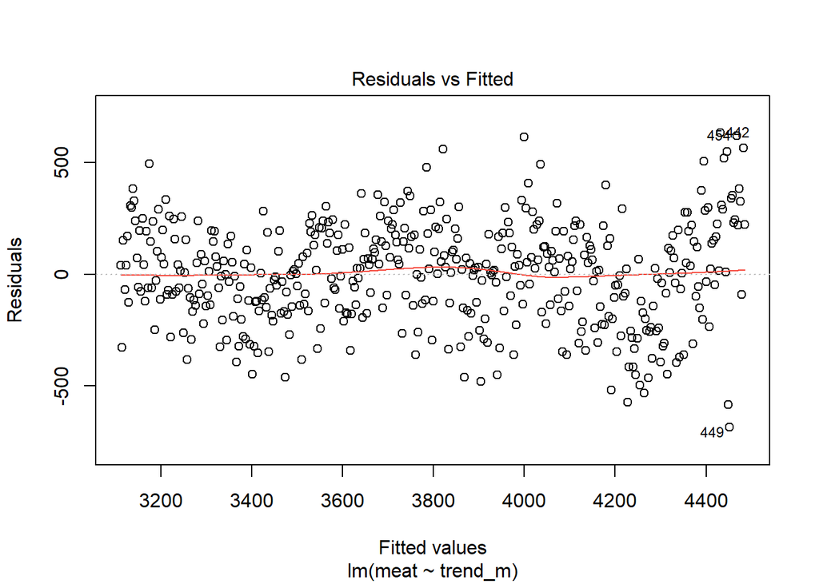

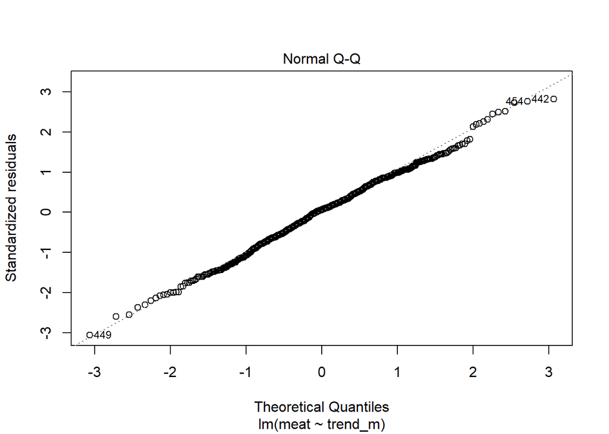

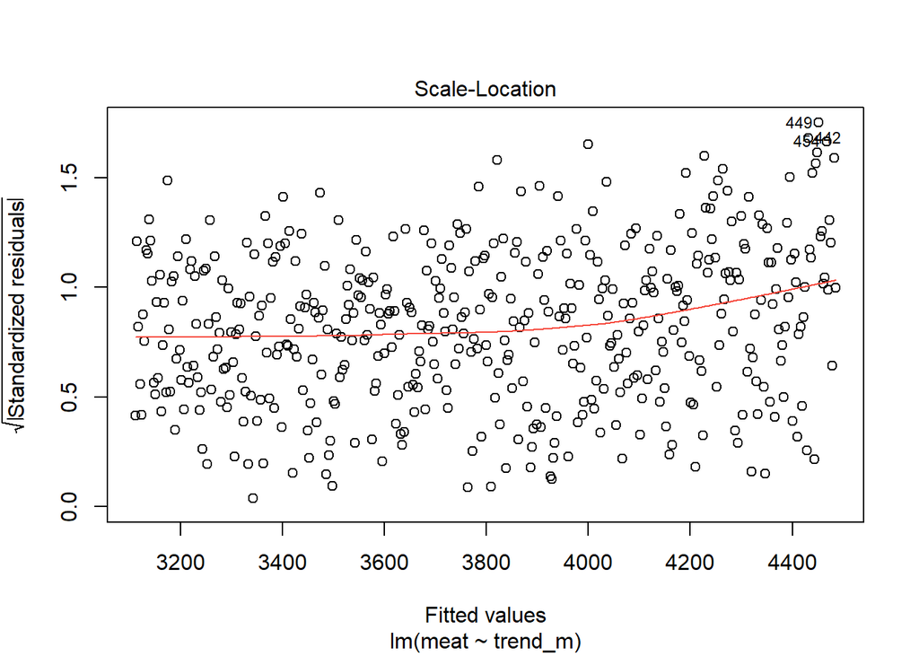

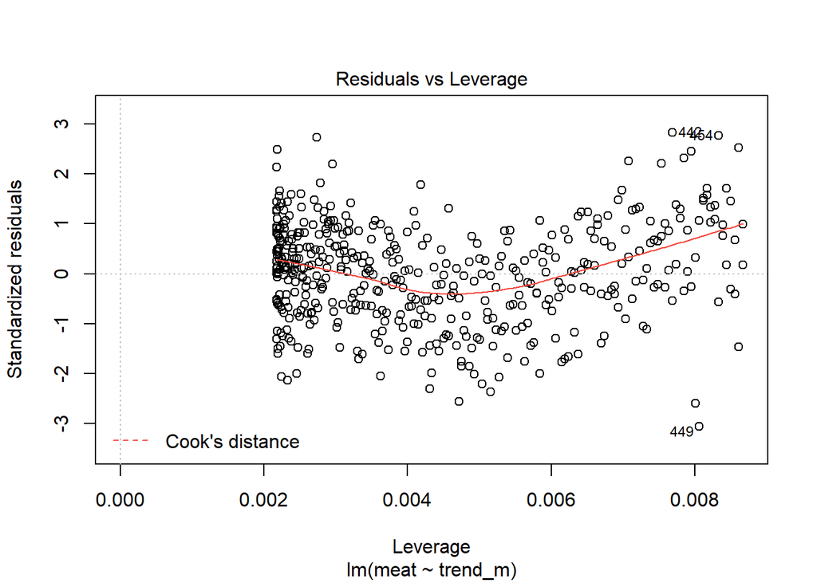

```r
plot(fit_m1)
```

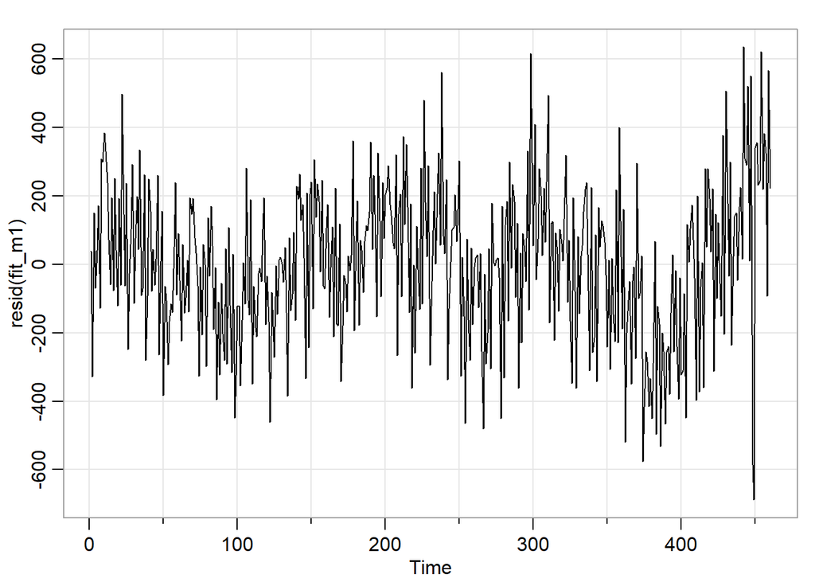

```r
tsplot(resid(fit_m1))
```

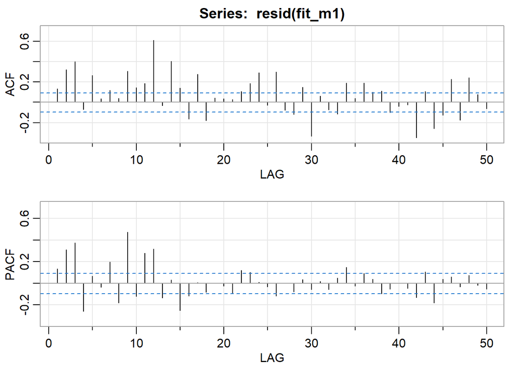

```r
acf2(resid(fit_m1), max.lag=50)
```

The time series plot suggests the possibility of a seasonal pattern in the data, and therefore autocorrelated errors. The correlograms confirm the presence of significant autocorrelation (within a confidence band of two standard errors).

**Seasonal:** It appears that at the seasons (s = 12) the ACF is tailing off at lags 1s, 2s, 3s, 4s. This slow decay indicates seasonal differencing. Typically, differencing of order one is sufficient to obtain seasonal stationarity. The PACF appears to cut off after lag 1s. These results imply an SAR(1), *P* = 1, *D* = 1, *Q* = 0, in the seasonal component.

**Non-Seasonal:** Inspecting the sample ACF and PACF at the first few lags, it appears as though the ACF tails off, whereas the PACF cuts off at lag 3. This suggests an AR(3) within the seasons, *p* = 3 and *q* = 0.

Therefore, I would choose the following model:

### Model Estimation: Total Meat Production

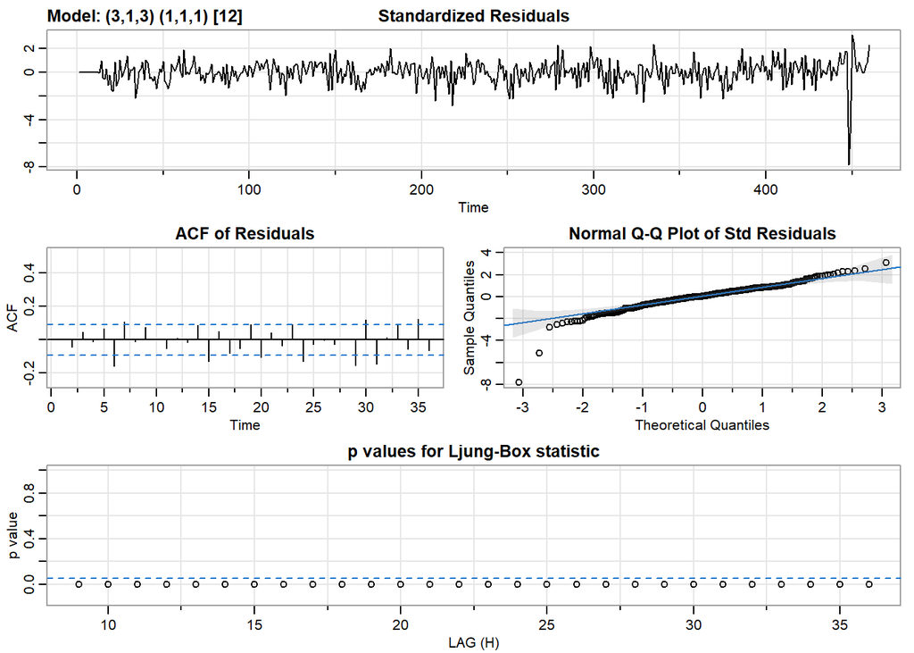

```r
sarima(meat, 3,1,3, 1,1,1,12, xreg=cbind(trend_m+pop+pop2))
```

### Forecasting: Total Meat Production

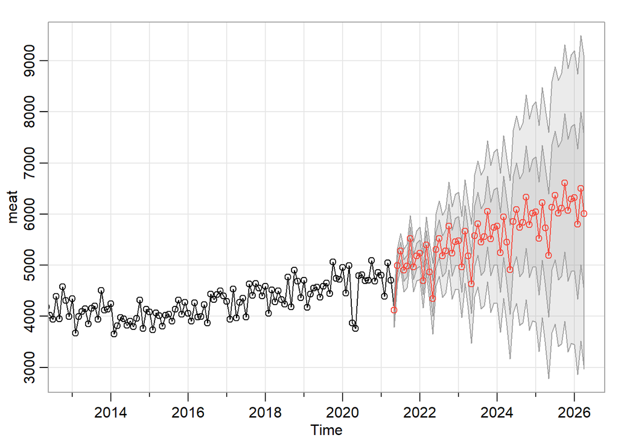

```r
# End of data set
data[which(data$Year==2021 & data$Month==4),] # row 460
meat = ts(meat, start = c(1983,1), frequency = 12)
sarima.for(meat, 60, 3,1,0, 1,1,0,12)
abline(v=460)
```

The forecasts out five years for total meat production is shown above.

### Model Formulation: Total Poultry Production

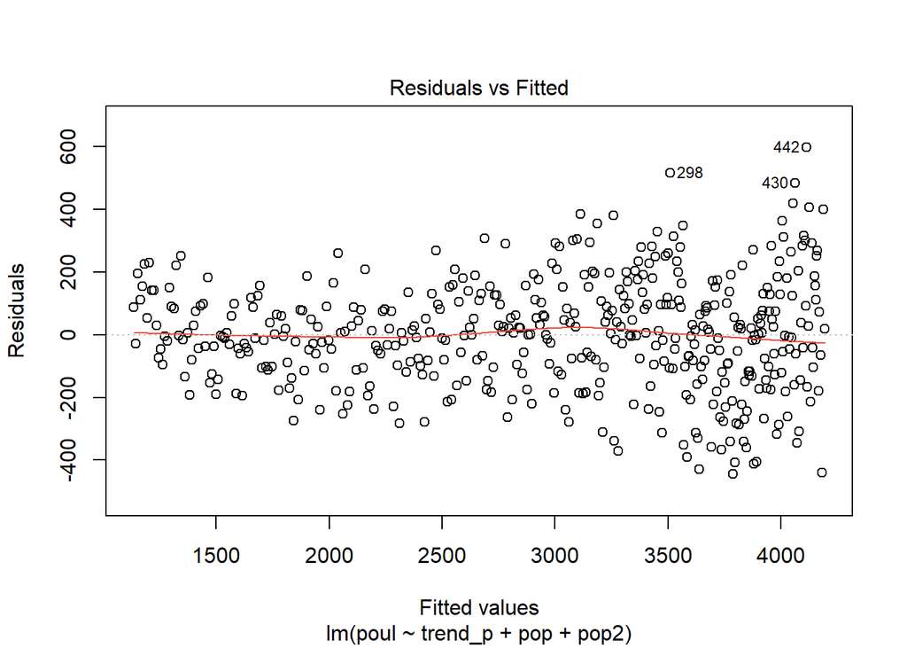

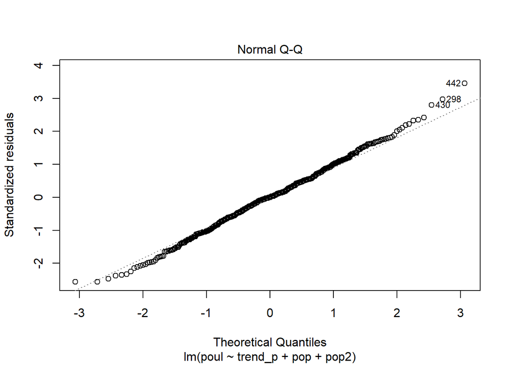

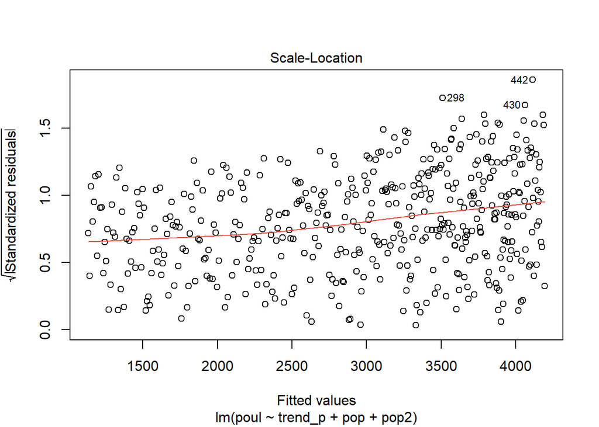

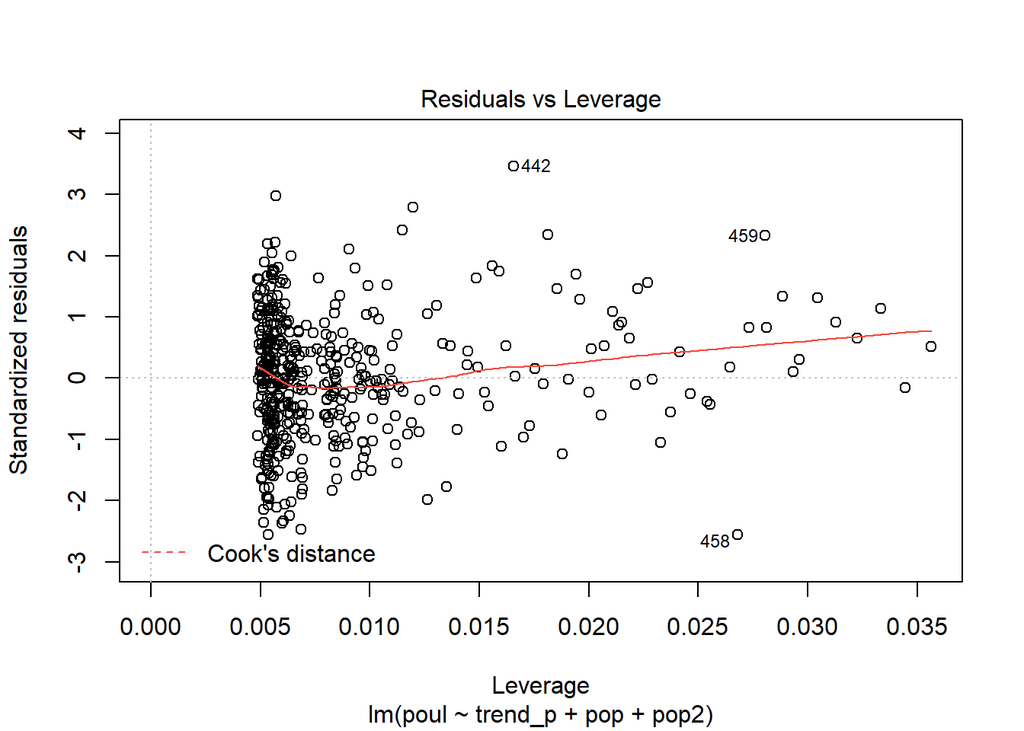

```r
plot(fit_p3)
```

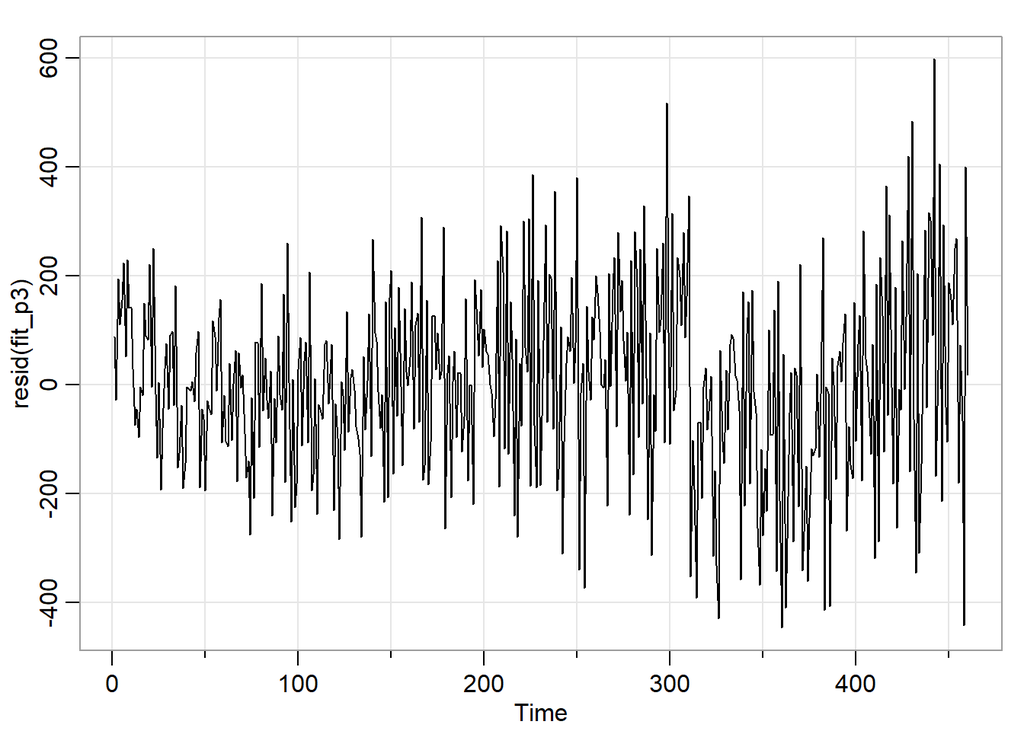

```r
tsplot(resid(fit_p3))
```

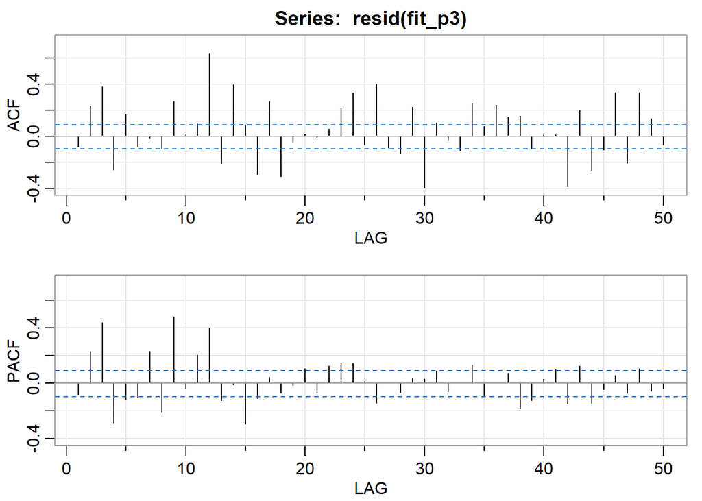

```r
acf2(resid(fit_p3), max.lag=50)
```

The residual plots for the P3 model suggest that the variance is nonconstant. Tne Q-Q plot shows that the assumption of normality is valid. There is a high-leverage outlier at month 459, corresponding to an unusual rise and fall in production for February and March 2021. The time series plot suggests a shifting trend, and therefore a lack of stationarity. Therefore, the data can be logged to stabilize the variance, then differenced to remove the trend.

The time series plot suggests the possibility of a seasonal pattern in the data, and therefore autocorrelated errors. The correlograms confirm the presence of significant autocorrelation (within a confidence band of two standard errors).

#### Transformations: Total Poultry Production

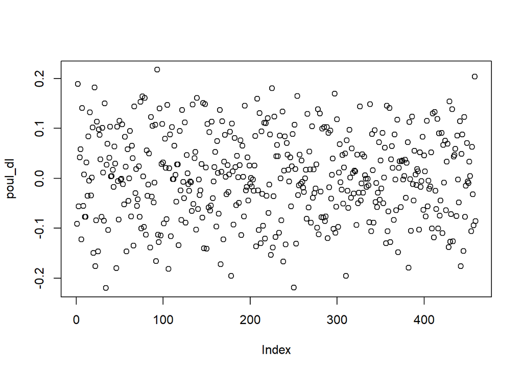

```r
poul_dl = diff(log(poul)) # apply logarithm, then difference
plot(poul_dl)
```

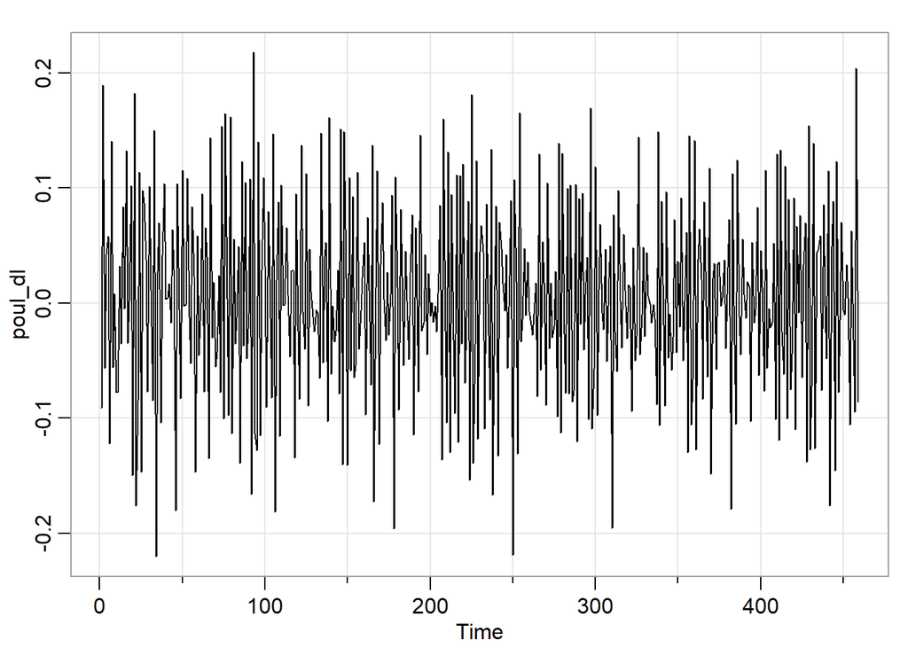

```r
tsplot(poul_dl)
```

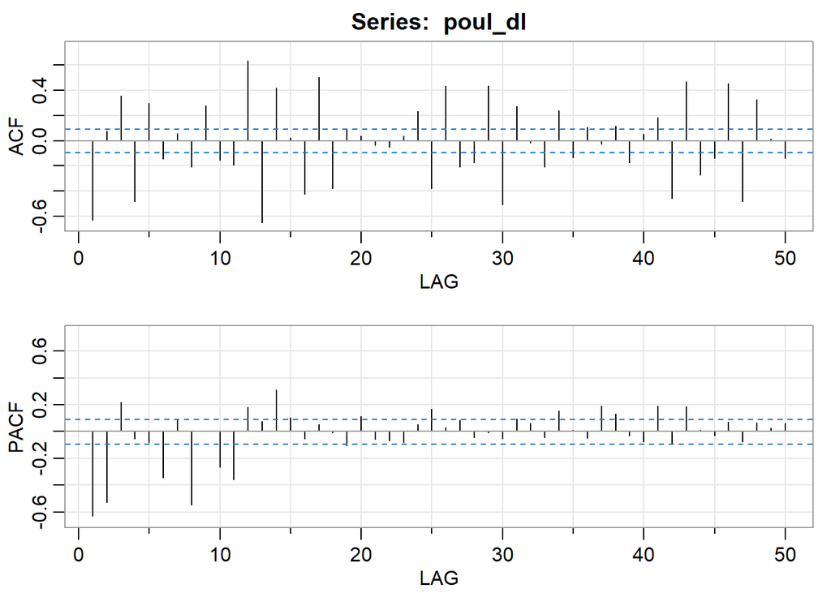

```r
acf2(poul_dl, max.lag=50)
```

**Seasonal:** It appears that at the seasons (s = 12) the ACF is tailing off at lags approximately near 1s, 2s, 3s, 4s. This slow decay indicates seasonal differencing. Typically, differencing of order one is sufficient to obtain seasonal stationarity. The PACF appears to cut off after about lag 1s. These results imply an SAR(1), *P* = 1, *D* = 1, *Q* = 0, in the seasonal component.

**Non-Seasonal:** Inspecting the sample ACF and PACF at the first few lags, it appears as though the ACF tails off, whereas the PACF cuts off at lag 2. This suggests and ARMA(2,0) within the seasons, *p* = 2 and *q* = 0.

Therefore, I would choose the following model:

### Model Estimation: Total Poultry Production

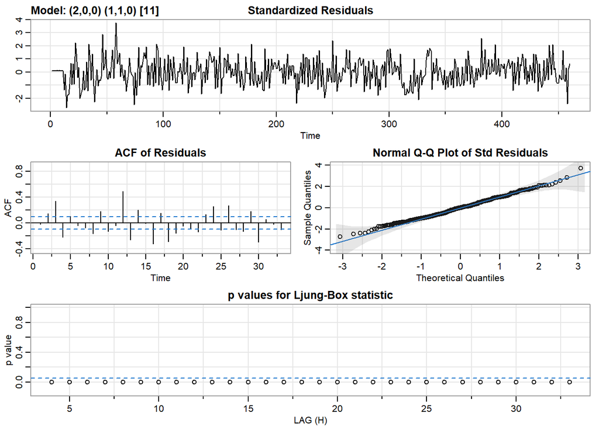

```r
sarima(log(poul), p=2,d=0,q=0, P=1,D=1,Q=0,S=11, xreg=cbind(trend_p, pop, pop2))
```

The plot of standardized residuals displays no obvious pattern. The ACF plot of residuals shows the presence of significant autocorrelation. the Q-Q plot suggests that the normality assumption is valid. The q-statistic has *p*-values that are all significant, leading to rejection of the null hypothesis that the residuals are white.

### Forecasting: Total Poultry Production

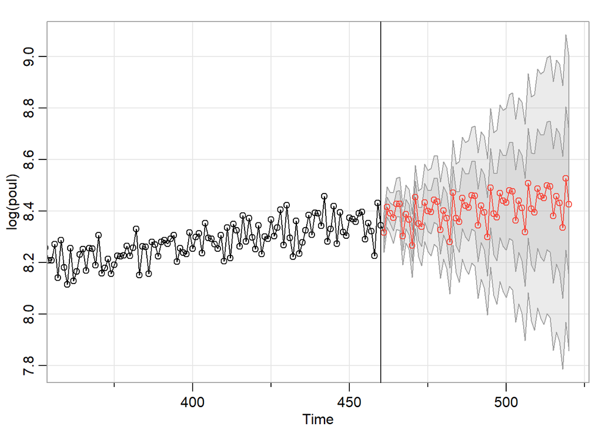

```r
sarima.for(log(poul), 60, 3,1,0, 1,1,0,12)
abline(v=460)
```

The forecasts out five years for the log of total poultry production is shown above.